# The female rivalry hypothesis - Main Experiments (sweeping over random seed)

Scott Claessens

2019-10-08

Load packages.

```r
library(tidyverse)
library(effsize)
library(gtable)
library(grid)
library(ggplotify)
```

Load data.

```r
d <-
  read.csv('data/ovulationRandomSeedMainExperiments.csv', header=T) %>%
  as_tibble() %>%
  mutate(Experiment = factor(Experiment),
         Run        = factor(Run),
         Decrement  = factor(Decrement),
         Strategy   = factor(Strategy))

d
```

| Experiment | Run | Decrement | Seed | Strategy | PI | RS |
| --- | --- | --- | --- | --- | --- | --- |
| 1 | 1 | TRUE | 1 | Concealers | 5997.62 | 6.76 |
| 1 | 2 | TRUE | 2 | Concealers | 5524.62 | 6.46 |
| 1 | 3 | TRUE | 3 | Concealers | 6031.10 | 6.68 |
| 1 | 4 | TRUE | 4 | Concealers | 5732.92 | 6.42 |
| 1 | 5 | TRUE | 5 | Concealers | 5281.14 | 6.22 |
| 1 | 6 | TRUE | 6 | Concealers | 7183.34 | 7.24 |
| 1 | 7 | TRUE | 7 | Concealers | 7164.22 | 7.24 |
| 1 | 8 | TRUE | 8 | Concealers | 6795.16 | 7.04 |
| 1 | 9 | TRUE | 9 | Concealers | 6005.46 | 6.80 |
| 1 | 10 | TRUE | 10 | Concealers | 6646.50 | 7.02 |

[output cut: 1190 more lines]

Our outcome variables are paternal investment (PI) and lifetime reproductive success (RS). There are 1200 rows in this dataset (3 experiments x 100 model runs x 2 decrement parameters x 2 female strategies). However, here, we sweep over random seed numbers to ensure they aren’t affecting our main results.

# Experiment 1 (No Aggression)

## Reproductive Success

Focusing on Experiment 1 first, visualise outcome and check assumptions of normality.

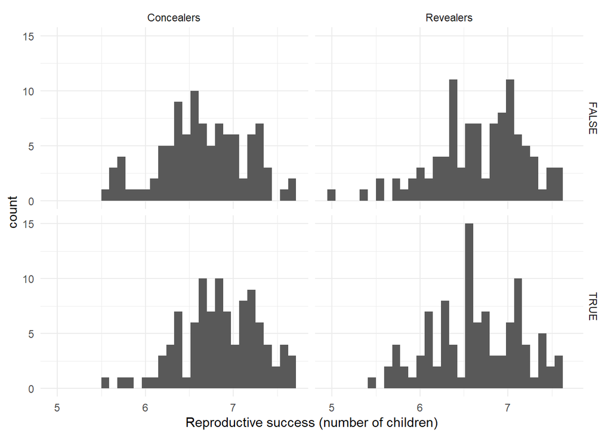

```r
d %>%
  filter(Experiment == 1) %>%

  ggplot(aes(x = RS)) +
  geom_histogram(bins=30) +
  facet_grid(Decrement ~ Strategy) +
  xlab('Reproductive success (number of children)') +
  theme_minimal()
```

These look approximately normally-distributed. Next, run paired t-tests to look for differences between strategies.

```r
RS.dFalse.Revealers  <- d %>% filter(Experiment==1, Decrement=='FALSE', Strategy=='Revealers') %>% pull(RS)
RS.dFalse.Concealers <- d %>% filter(Experiment==1, Decrement=='FALSE', Strategy=='Concealers') %>% pull(RS)
RS.dTrue.Revealers   <- d %>% filter(Experiment==1, Decrement=='TRUE', Strategy=='Revealers') %>% pull(RS)
RS.dTrue.Concealers  <- d %>% filter(Experiment==1, Decrement=='TRUE', Strategy=='Concealers') %>% pull(RS)

t.test(RS.dFalse.Revealers, RS.dFalse.Concealers, paired = TRUE)
```

```
##
##  Paired t-test
##
## data:  RS.dFalse.Revealers and RS.dFalse.Concealers
## t = 0.42061, df = 99, p-value = 0.675
## alternative hypothesis: true difference in means is not equal to 0
## 95 percent confidence interval:
##  -0.09293794  0.14293794
## sample estimates:
## mean of the differences
##                   0.025
```

```r
cohen.d(RS.dFalse.Revealers, RS.dFalse.Concealers, paired = TRUE)
```

```
##
## Cohen's d
##
## d estimate: 0.04951608 (negligible)
## 95 percent confidence interval:
##      lower      upper
## -0.1827829  0.2818151
```

When Decrement == FALSE, there is no difference between the reproductive success of Revealers (Mean = 6.68 children) and Concealers (Mean = 6.65 children), with an effect size of 0.05.

```r
t.test(RS.dTrue.Revealers, RS.dTrue.Concealers, paired = TRUE)
```

```
##
##  Paired t-test
##
## data:  RS.dTrue.Revealers and RS.dTrue.Concealers
## t = -3.9272, df = 99, p-value = 0.000159
## alternative hypothesis: true difference in means is not equal to 0
## 95 percent confidence interval:
##  -0.3386812 -0.1113188
## sample estimates:
## mean of the differences
##                  -0.225
```

```r
cohen.d(RS.dTrue.Revealers, RS.dTrue.Concealers, paired = TRUE)
```

```
##
## Cohen's d
##
## d estimate: -0.4713389 (small)
## 95 percent confidence interval:
##      lower      upper
## -0.7208176 -0.2218601
```

When Decrement == TRUE, there is a significant difference between the reproductive success of Revealers (Mean = 6.63 children) and Concealers (Mean = 6.86 children), with an effect size of -0.47.

## Paternal Investment

Now we check the PI outcome, in Experiment 1.

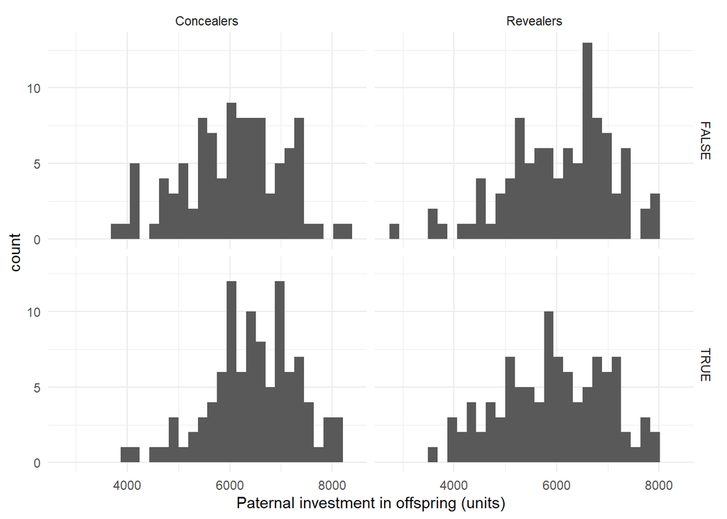

```r
d %>%
  filter(Experiment == 1) %>%

  ggplot(aes(x = PI)) +
  geom_histogram(bins=30) +
  facet_grid(Decrement ~ Strategy) +
  xlab('Paternal investment in offspring (units)') +
  theme_minimal()
```

These also look approximately normally-distributed. Run paired t-tests to look for differences between strategies.

```r
PI.dFalse.Revealers  <- d %>% filter(Experiment==1, Decrement=='FALSE', Strategy=='Revealers') %>% pull(PI)
PI.dFalse.Concealers <- d %>% filter(Experiment==1, Decrement=='FALSE', Strategy=='Concealers') %>% pull(PI)
PI.dTrue.Revealers   <- d %>% filter(Experiment==1, Decrement=='TRUE', Strategy=='Revealers') %>% pull(PI)
PI.dTrue.Concealers  <- d %>% filter(Experiment==1, Decrement=='TRUE', Strategy=='Concealers') %>% pull(PI)

t.test(PI.dFalse.Revealers, PI.dFalse.Concealers, paired = TRUE)
```

```
##
##  Paired t-test
##
## data:  PI.dFalse.Revealers and PI.dFalse.Concealers
## t = -0.043897, df = 99, p-value = 0.9651
## alternative hypothesis: true difference in means is not equal to 0
## 95 percent confidence interval:
##  -280.5808  268.4348
## sample estimates:
## mean of the differences
##                  -6.073
```

```r
cohen.d(PI.dFalse.Revealers, PI.dFalse.Concealers, paired = TRUE)
```

```
##
## Cohen's d
##
## d estimate: -0.00599689 (negligible)
## 95 percent confidence interval:
##      lower      upper
## -0.2754003  0.2634065
```

When Decrement == FALSE, there is no significant difference between the paternal investment of Revealers (Mean = 6055 units) and Concealers (Mean = 6061 units), with an effect size of -0.01.

```r
t.test(PI.dTrue.Revealers, PI.dTrue.Concealers, paired = TRUE)
```

```
##
##  Paired t-test
##
## data:  PI.dTrue.Revealers and PI.dTrue.Concealers
## t = -4.0227, df = 99, p-value = 0.0001125
## alternative hypothesis: true difference in means is not equal to 0
## 95 percent confidence interval:
##  -789.6720 -267.9828
## sample estimates:
## mean of the differences
##               -528.8274
```

```r
cohen.d(PI.dTrue.Revealers, PI.dTrue.Concealers, paired = TRUE)
```

```
##
## Cohen's d
##
## d estimate: -0.555827 (medium)
## 95 percent confidence interval:
##      lower      upper
## -0.8485932 -0.2630609
```

When Decrement == TRUE, there is a significant difference between the paternal investment of Revealers (Mean = 5935 units) and Concealers (Mean = 6464 units), with an effect size of -0.56.

# Experiment 2 (Aggression Towards Higher Mate Value Females)

## Reproductive Success

Now we turn to Experiment 2. For reproductive success, visualise outcome and check assumptions of normality.

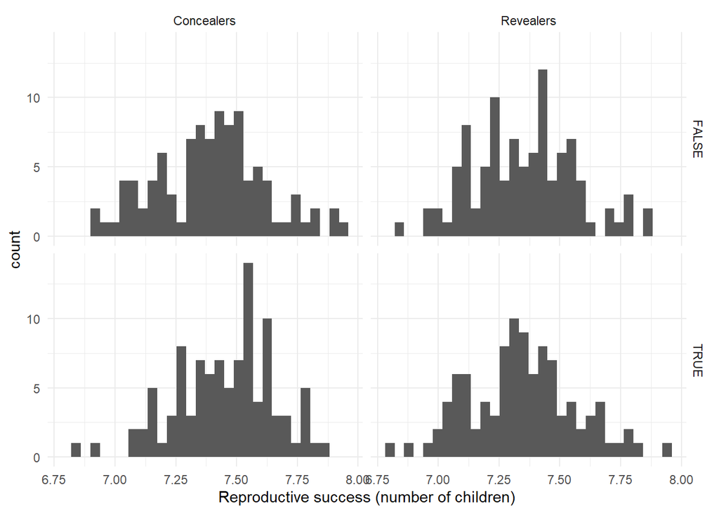

```r
d %>%
  filter(Experiment == 2) %>%

  ggplot(aes(x = RS)) +
  geom_histogram(bins=30) +
  facet_grid(Decrement ~ Strategy) +
  xlab('Reproductive success (number of children)') +
  theme_minimal()
```

As before, these are approximately normally-distributed. Next, run paired t-tests to look for differences between strategies.

```r
RS.dFalse.Revealers  <- d %>% filter(Experiment==2, Decrement=='FALSE', Strategy=='Revealers') %>% pull(RS)
RS.dFalse.Concealers <- d %>% filter(Experiment==2, Decrement=='FALSE', Strategy=='Concealers') %>% pull(RS)
RS.dTrue.Revealers   <- d %>% filter(Experiment==2, Decrement=='TRUE', Strategy=='Revealers') %>% pull(RS)
RS.dTrue.Concealers  <- d %>% filter(Experiment==2, Decrement=='TRUE', Strategy=='Concealers') %>% pull(RS)

t.test(RS.dFalse.Revealers, RS.dFalse.Concealers, paired = TRUE)
```

```
##
##  Paired t-test
##
## data:  RS.dFalse.Revealers and RS.dFalse.Concealers
## t = -1.3256, df = 99, p-value = 0.188
## alternative hypothesis: true difference in means is not equal to 0
## 95 percent confidence interval:
##  -0.11485438  0.02285438
## sample estimates:
## mean of the differences
##                  -0.046
```

```r
cohen.d(RS.dFalse.Revealers, RS.dFalse.Concealers, paired = TRUE)
```

```
##
## Cohen's d
##
## d estimate: -0.2067548 (small)
## 95 percent confidence interval:
##      lower      upper
## -0.5175993  0.1040897
```

When Decrement == FALSE, there is no significant difference between the reproductive success of Revealers (Mean = 7.35 children) and Concealers (Mean = 7.4 children), with an effect size of -0.21.

```r
t.test(RS.dTrue.Revealers, RS.dTrue.Concealers, paired = TRUE)
```

```
##
##  Paired t-test
##
## data:  RS.dTrue.Revealers and RS.dTrue.Concealers
## t = -3.3945, df = 99, p-value = 0.0009902
## alternative hypothesis: true difference in means is not equal to 0
## 95 percent confidence interval:
##  -0.17303082 -0.04536918
## sample estimates:
## mean of the differences
##                 -0.1092
```

```r
cohen.d(RS.dTrue.Revealers, RS.dTrue.Concealers, paired = TRUE)
```

```
##
## Cohen's d
##
## d estimate: -0.5137784 (medium)
## 95 percent confidence interval:
##      lower      upper
## -0.8313381 -0.1962187
```

When Decrement == TRUE, there is a significant difference between the reproductive success of Revealers (Mean = 7.34 children) and Concealers (Mean = 7.45 children), with an effect size of -0.51.

## Paternal Investment

Now we check the PI outcome, in Experiment 2.

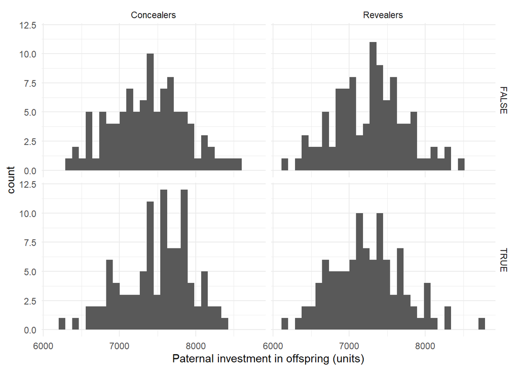

```r
d %>%
  filter(Experiment == 2) %>%

  ggplot(aes(x = PI)) +
  geom_histogram(bins=30) +
  facet_grid(Decrement ~ Strategy) +
  xlab('Paternal investment in offspring (units)') +
  theme_minimal()
```

These also look normally-distributed. Run paired t-tests to look for differences between strategies.

```r
PI.dFalse.Revealers  <- d %>% filter(Experiment==2, Decrement=='FALSE', Strategy=='Revealers') %>% pull(PI)
PI.dFalse.Concealers <- d %>% filter(Experiment==2, Decrement=='FALSE', Strategy=='Concealers') %>% pull(PI)
PI.dTrue.Revealers   <- d %>% filter(Experiment==2, Decrement=='TRUE', Strategy=='Revealers') %>% pull(PI)
PI.dTrue.Concealers  <- d %>% filter(Experiment==2, Decrement=='TRUE', Strategy=='Concealers') %>% pull(PI)

t.test(PI.dFalse.Revealers, PI.dFalse.Concealers, paired = TRUE)
```

```
##
##  Paired t-test
##
## data:  PI.dFalse.Revealers and PI.dFalse.Concealers
## t = -1.3574, df = 99, p-value = 0.1777
## alternative hypothesis: true difference in means is not equal to 0
## 95 percent confidence interval:
##  -247.44327   46.41607
## sample estimates:
## mean of the differences
##               -100.5136
```

```r
cohen.d(PI.dFalse.Revealers, PI.dFalse.Concealers, paired = TRUE)
```

```
##
## Cohen's d
##
## d estimate: -0.2095579 (small)
## 95 percent confidence interval:
##       lower       upper
## -0.51732817  0.09821238
```

When Decrement == FALSE, there is no significant difference between the paternal investment of Revealers (Mean = 7278 units) and Concealers (Mean = 7379 units), with an effect size of -0.21.

```r
t.test(PI.dTrue.Revealers, PI.dTrue.Concealers, paired = TRUE)
```

```
##
##  Paired t-test
##
## data:  PI.dTrue.Revealers and PI.dTrue.Concealers
## t = -3.5529, df = 99, p-value = 0.0005855
## alternative hypothesis: true difference in means is not equal to 0
## 95 percent confidence interval:
##  -392.2923 -111.1377
## sample estimates:
## mean of the differences
##                -251.715
```

```r
cohen.d(PI.dTrue.Revealers, PI.dTrue.Concealers, paired = TRUE)
```

```
##
## Cohen's d
##
## d estimate: -0.5418977 (medium)
## 95 percent confidence interval:
##      lower      upper
## -0.8640000 -0.2197954
```

When Decrement == TRUE, there is a significant difference between the paternal investment of Revealers (Mean = 7242 units) and Concealers (Mean = 7494 units), with an effect size of -0.54.

# Experiment 3 (Aggression Towards Ovulating Females)

## Reproductive Success

Finally, we turn to Experiment 3. For reproductive success, visualise outcome and check assumptions of normality.

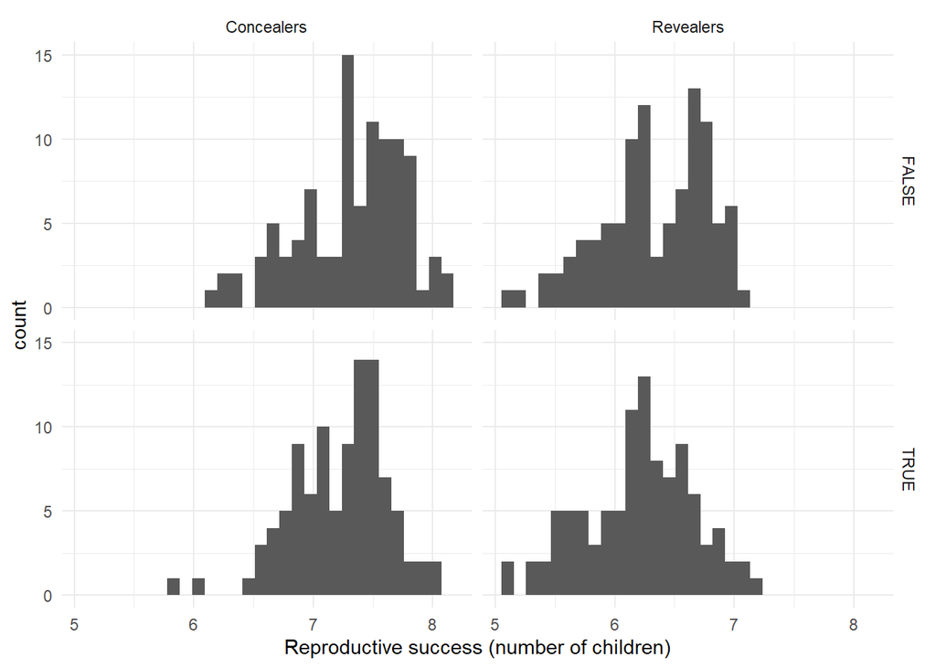

```r
d %>%
  filter(Experiment == 3) %>%

  ggplot(aes(x = RS)) +
  geom_histogram(bins=30) +
  facet_grid(Decrement ~ Strategy) +
  xlab('Reproductive success (number of children)') +
  theme_minimal()
```

As before, these appear normally-distributed. Next, run paired t-tests.

```r
RS.dFalse.Revealers  <- d %>% filter(Experiment==3, Decrement=='FALSE', Strategy=='Revealers') %>% pull(RS)
RS.dFalse.Concealers <- d %>% filter(Experiment==3, Decrement=='FALSE', Strategy=='Concealers') %>% pull(RS)
RS.dTrue.Revealers   <- d %>% filter(Experiment==3, Decrement=='TRUE', Strategy=='Revealers') %>% pull(RS)
RS.dTrue.Concealers  <- d %>% filter(Experiment==3, Decrement=='TRUE', Strategy=='Concealers') %>% pull(RS)

t.test(RS.dFalse.Revealers, RS.dFalse.Concealers, paired = TRUE)
```

```
##
##  Paired t-test
##
## data:  RS.dFalse.Revealers and RS.dFalse.Concealers
## t = -36.33, df = 99, p-value < 2.2e-16
## alternative hypothesis: true difference in means is not equal to 0
## 95 percent confidence interval:
##  -1.0305705 -0.9238295
## sample estimates:
## mean of the differences
##                 -0.9772
```

```r
cohen.d(RS.dFalse.Revealers, RS.dFalse.Concealers, paired = TRUE)
```

```
##
## Cohen's d
##
## d estimate: -2.184644 (large)
## 95 percent confidence interval:
##     lower     upper
## -2.402859 -1.966428
```

When Decrement == FALSE, there is a significant difference between the reproductive success of Revealers (Mean = 6.34 children) and Concealers (Mean = 7.31 children), with an effect size of -2.18.

```r
t.test(RS.dTrue.Revealers, RS.dTrue.Concealers, paired = TRUE)
```

```
##
##  Paired t-test
##
## data:  RS.dTrue.Revealers and RS.dTrue.Concealers
## t = -35.386, df = 99, p-value < 2.2e-16
## alternative hypothesis: true difference in means is not equal to 0
## 95 percent confidence interval:
##  -1.0822641 -0.9673359
## sample estimates:
## mean of the differences
##                 -1.0248
```

```r
cohen.d(RS.dTrue.Revealers, RS.dTrue.Concealers, paired = TRUE)
```

```
##
## Cohen's d
##
## d estimate: -2.324855 (large)
## 95 percent confidence interval:
##     lower     upper
## -2.574155 -2.075556
```

When Decrement == TRUE, there is again a significant difference between the reproductive success of Revealers (Mean = 6.2 children) and Concealers (Mean = 7.22 children), with an effect size of -2.32.

## Paternal Investment

Now we check the PI outcome, in Experiment 3.

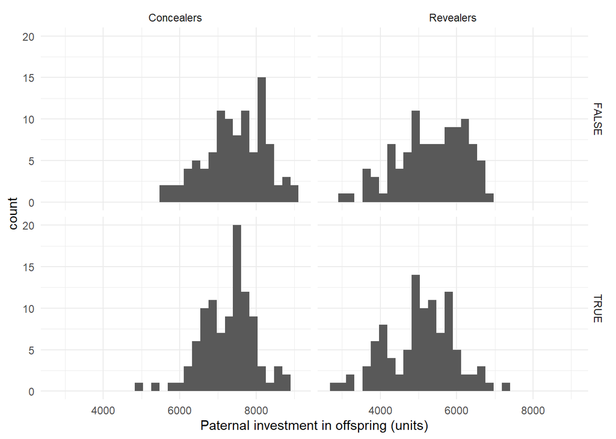

```r
d %>%
  filter(Experiment == 3) %>%

  ggplot(aes(x = PI)) +
  geom_histogram(bins=30) +
  facet_grid(Decrement ~ Strategy) +
  xlab('Paternal investment in offspring (units)') +
  theme_minimal()
```

These also look normally-distributed. Run paired t-tests to look for differences between strategies.

```r
PI.dFalse.Revealers  <- d %>% filter(Experiment==3, Decrement=='FALSE', Strategy=='Revealers') %>% pull(PI)
PI.dFalse.Concealers <- d %>% filter(Experiment==3, Decrement=='FALSE', Strategy=='Concealers') %>% pull(PI)
PI.dTrue.Revealers   <- d %>% filter(Experiment==3, Decrement=='TRUE', Strategy=='Revealers') %>% pull(PI)
PI.dTrue.Concealers  <- d %>% filter(Experiment==3, Decrement=='TRUE', Strategy=='Concealers') %>% pull(PI)

t.test(PI.dFalse.Revealers, PI.dFalse.Concealers, paired = TRUE)
```

```
##
##  Paired t-test
##
## data:  PI.dFalse.Revealers and PI.dFalse.Concealers
## t = -36.901, df = 99, p-value < 2.2e-16
## alternative hypothesis: true difference in means is not equal to 0
## 95 percent confidence interval:
##  -2245.377 -2016.228
## sample estimates:
## mean of the differences
##               -2130.802
```

```r
cohen.d(PI.dFalse.Revealers, PI.dFalse.Concealers, paired = TRUE)
```

```
##
## Cohen's d
##
## d estimate: -2.523243 (large)
## 95 percent confidence interval:
##     lower     upper
## -2.799040 -2.247445
```

When Decrement == FALSE, there is a significant difference between the paternal investment of Revealers (Mean = 5321 units) and Concealers (Mean = 7452 units), with an effect size of -2.52.

```r
t.test(PI.dTrue.Revealers, PI.dTrue.Concealers, paired = TRUE)
```

```
##
##  Paired t-test
##
## data:  PI.dTrue.Revealers and PI.dTrue.Concealers
## t = -34.891, df = 99, p-value < 2.2e-16
## alternative hypothesis: true difference in means is not equal to 0
## 95 percent confidence interval:
##  -2319.621 -2069.992
## sample estimates:
## mean of the differences
##               -2194.807
```

```r
cohen.d(PI.dTrue.Revealers, PI.dTrue.Concealers, paired = TRUE)
```

```
##
## Cohen's d
##
## d estimate: -2.661553 (large)
## 95 percent confidence interval:
##     lower     upper
## -2.982141 -2.340966
```

When Decrement == TRUE, there is a significant difference between the paternal investment of Revealers (Mean = 5065 units) and Concealers (Mean = 7260 units), with an effect size of -2.66.

# Plotting the results of the main experiments

We create violin plot summarising our outcomes for both Concealers and Revealers, when decrement is both True and False, in all three Experiments. The code is hidden here (see the source .Rmd file), but this is the result for reproductive success:

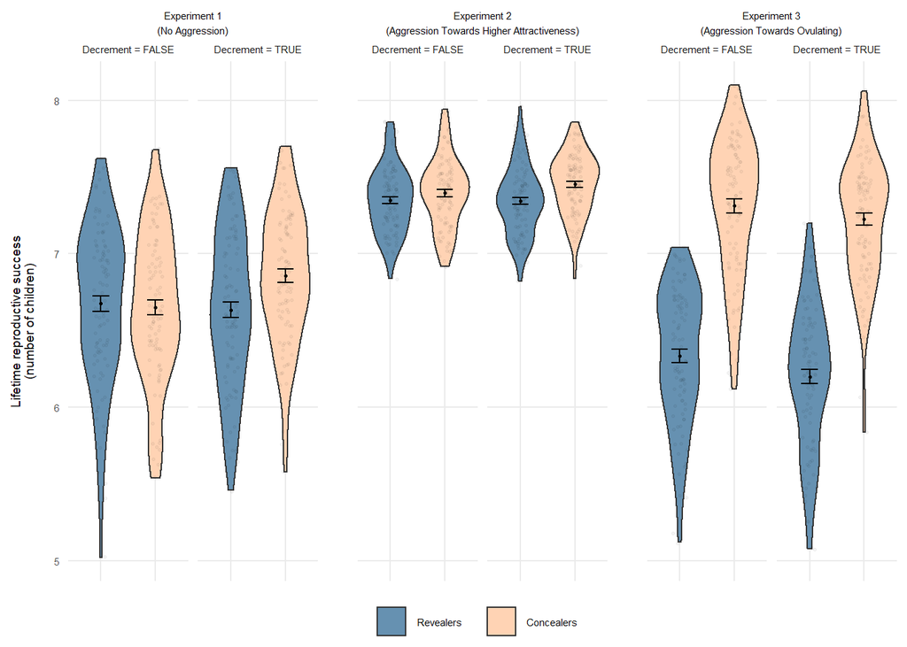

And the plot for paternal investment:

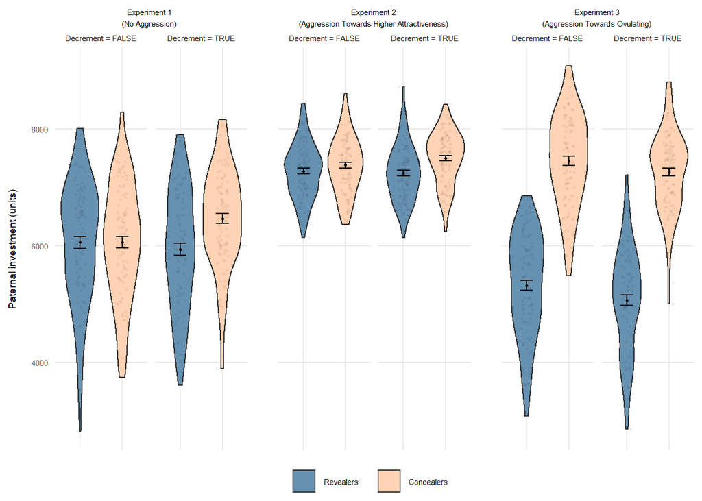